### Required input files

1. “ct.ipm.txt”  
   columns: n == Unique number for each individual  
   site == Population abbreviation (here: FU == Furka Pass, SP == Schynige Platte)  
   year.t == here: 2004 or 2005  
   nl.t == number of rosette leaves in year t  
   nl.t1 == number of rosette leaves in year t+1  
   ll.t == length of longest rosette leave in year t  
   ll.t1 == length of longest rosette leave in year t+1  
   surv == survival: 1 == yes, 0 == no  
   flow == flowering: 1 == yes, 0 == no  
   ros == number of rosettes in individual
2. “ct.IPM.fecundity.txt”  
   columns: n == Unique number for each individual  
   site == Population abbreviation (here: FU == Furka Pass, SP == Schynige Platte)  
   year.t == here: 2004 or 2005  
   ll.t == length of longest rosette leave in year t  
   nl.t == number of rosette leaves in year t  
   si.t1 == seeds per individual in year t+1  
   brows.t1 == browsed in year t+1 (here: 1 ==Yes, 0 == No)  
   ros == number of rosettes in individual  
   size.t == size in year t
3. “CT.IPM.seedlings.txt”  
   columns: n == Unique number for each individual  
   site == Population abbreviation (here: FU == Furka Pass, SP == Schynige Platte)  
   year.t == here: 2004 or 2005  
   ll.t == length of longest rosette leave in year t  
   nl.t == number of rosette leaves in year t  
   size.t == size in year t
4. “IPM.establishment.data.txt”  
   columns: site == Population abbreviation (here: FU == Furka Pass, SP == Schynige Platte)  
   plot == Number of plot  
   year.t == here: 2004 or 2005  
   seeds.t == seed production in each plot  
   sdl.t1 == seedlings in year t+1 in each plot
5. “ipm.saf.data.txt”  
   columns: n == Unique number for each individual  
   site == Population abbreviation (here: FU == Furka Pass, SP == Schynige Platte)  
   flo == Flowering (here: 1==Yes, 0==NO)  
   age == Age 2005

#### Load packages

```r
# Clear environment
rm(list=ls())

# Load packages
library(tidyverse)
library(nlme)
library(MASS)
library(cowplot)

setwd("~/Desktop/IQ/Rotation2/rotation2_thyrsoides")

# Detach any lingering attached datafs
while(any(search()=="dataf_r1")) detach(dataf_r1)
```

## Part I. Fitting Models

#### Read first in dataset

```r
dataf = data.frame(read.table("ct.ipm.txt",header=T))
# names(dataf)

# attach(dataf) ## Set reference dataframe

# Filter full dataframe for plants with 1 rosette
dataf_r1 = filter(dataf,ros==1)
attach(dataf_r1)

dataf_r1$size.t.all = log(nl.t*ll.t) ## plant sizes in year t

dataf_r1$size.t1.all = log(nl.t1*ll.t1) ## plant sizes in year t+1

## The next three are unnecessary since they are just duplicating data in another column, but keeping for consistency at this point
dataf_r1$flow.all = flow ## Logical vector if flowering: 1 = yes
dataf_r1$surv.all = surv ## Logical vector of survival: 1 = yes
dataf_r1$site.all = site ## Site vector

site.code.l=c("FU","SP") ## Used later for plots
pch.code=c(19,1)

# Detach old version, attach new version
detach(dataf_r1)
attach(dataf_r1)

all.sizes=c(size.t.all[flow.all==0],size.t1.all[year.t==2005]) ## all plant sizes
all.site=c(site.all[flow.all==0],site.all[year.t==2005]) ## All sites -- how is this one used?
detach(dataf_r1)
```

#### Calculation: Growth

```r
growth_df <- dataf_r1 %>%
  filter(flow.all==0) %>%
  dplyr::select(size.t = size.t.all,
                size.t1 = size.t1.all,
                site.s = site.all) %>%
  filter(complete.cases(.))

######### check whether variance structure is needed #########
## AKA check for heterogeneity?
fit.grow.gls.1<-gls(size.t1~size.t+site.s,
                    na.action=na.omit,
                    weight=varExp(form=~fitted(.)|site.s), ## Exponential of the variance covariate grouped at site level?
                    method="ML",
                    data=growth_df); ## Maximum likelihood
# summary(fit.grow.gls.1)
# plot(fit.grow.gls.1) ##

fit.grow.gls<-gls(size.t1~size.t+site.s,
                  na.action=na.omit,
                  weight=varExp(form=~fitted(.)), ## Exponential variance function structure of fitted data
                  method="ML",
                  data=growth_df);
# summary(fit.grow.gls)
# plot(fit.grow.gls) ##

fit.grow.gls.0<-gls(size.t1~size.t+site.s,
                    na.action=na.omit,
                    ## no weight used
                    method="ML",
                    data=growth_df);
# summary(fit.grow.gls.0)
# plot(fit.grow.gls.0) ##

## Compare models
anova(fit.grow.gls.0,fit.grow.gls,fit.grow.gls.1)
```

```
##                Model df      AIC      BIC    logLik   Test   L.Ratio
## fit.grow.gls.0     1  4 1803.644 1823.627 -897.8221
## fit.grow.gls       2  5 1648.528 1673.507 -819.2639 1 vs 2 157.11630
## fit.grow.gls.1     3  6 1627.669 1657.643 -807.8344 2 vs 3  22.85915
##                p-value
## fit.grow.gls.0
## fit.grow.gls    <.0001
## fit.grow.gls.1  <.0001
```

```r
# Remove models from environments
rm(fit.grow.gls,fit.grow.gls.0,fit.grow.gls.1)

######### check whether intercept estimate for habitat is needed #########
fit.grow.gls.0<-gls(size.t1~size.t, ## size only
                    na.action=na.omit,
                    weight=varExp(form=~fitted(.)|site.s),
                    method="ML",
                    data=growth_df);
# plot(fit.grow.gls.0)

fit.grow.gls.1<-gls(size.t1~size.t+site.s, ## size + site as independent terms
                    na.action=na.omit,
                    weight=varExp(form=~fitted(.)|site.s),
                    method="ML",
                    data=growth_df)
# plot(fit.grow.gls.1)

fit.grow.gls.2<-gls(size.t1~size.t*site.s, ## size*site as interaction term
                    na.action=na.omit,
                    weight=varExp(form=~fitted(.)|site.s),
                    method="ML",
                    data=growth_df)
# plot(fit.grow.gls.2)

## Compare models
anova(fit.grow.gls.0,fit.grow.gls.1,fit.grow.gls.2)
```

```
##                Model df      AIC      BIC    logLik   Test   L.Ratio
## fit.grow.gls.0     1  5 1636.038 1661.017 -813.0191
## fit.grow.gls.1     2  6 1627.669 1657.643 -807.8344 1 vs 2 10.369433
## fit.grow.gls.2     3  7 1627.092 1662.062 -806.5459 2 vs 3  2.576921
##                p-value
## fit.grow.gls.0
## fit.grow.gls.1  0.0013
## fit.grow.gls.2  0.1084
```

```r
# Remove models from environment
rm(fit.grow.gls.0,fit.grow.gls.1,fit.grow.gls.2)

######### refit model with size and site main effects, and site specific decreasing variance #########
fit.grow.gls<-gls(size.t1~site.s+size.t-1, ## Why -1?
                  na.action=na.omit,
                  weight=varExp(form=~fitted(.)|site.s),
                  method="ML",
                  data=growth_df)

summary(fit.grow.gls)
```

```
## Generalized least squares fit by maximum likelihood
##   Model: size.t1 ~ site.s + size.t - 1
##   Data: growth_df
##        AIC      BIC    logLik
##   1627.669 1657.643 -807.8344
##
## Variance function:
##  Structure: Exponential of variance covariate, different strata
##  Formula: ~fitted(.) | site.s
##  Parameter estimates:
##         FU         SP
## -0.2455818 -0.2115804
##
## Coefficients:
##             Value  Std.Error  t-value p-value
## site.sFU 1.175113 0.08097083 14.51280       0
## site.sSP 1.067800 0.08598521 12.41841       0
## size.t   0.882743 0.01269721 69.52259       0
##
##  Correlation:
##          st.sFU st.sSP
## site.sSP  0.922
## size.t   -0.979 -0.942
##
## Standardized residuals:
##         Min          Q1         Med          Q3         Max
## -4.74270213 -0.64741828 -0.06019704  0.56735452  4.13082080
##
## Residual standard error: 2.145755
## Degrees of freedom: 1092 total; 1089 residual
```

```r
intervals(fit.grow.gls) ## Confidence intervals on the parameters associated with the model
```

```
## Approximate 95% confidence intervals
##
##  Coefficients:
##              lower     est.     upper
## site.sFU 1.0162366 1.175113 1.3339895
## site.sSP 0.8990843 1.067800 1.2365151
## size.t   0.8578292 0.882743 0.9076568
## attr(,"label")
## [1] "Coefficients:"
##
##  Variance function:
##         lower       est.      upper
## FU -0.2824338 -0.2455818 -0.2087297
## SP -0.2490239 -0.2115804 -0.1741368
## attr(,"label")
## [1] "Variance function:"
##
##  Residual standard error:
##    lower     est.    upper
## 1.707969 2.145755 2.695754
```

```r
g.intercepts=fit.grow.gls$coef[1:2] ## Growth intercepts for each site
g.slopes=rep(fit.grow.gls$coef[3],2) ## Growth slopes for each site
var.exp.coef=fit.grow.gls$modelStruct$varStruct ## coef for variance structure
sigma.g=fit.grow.gls$sigma ## Residual standard error
```

#### Plot: Annual Growth

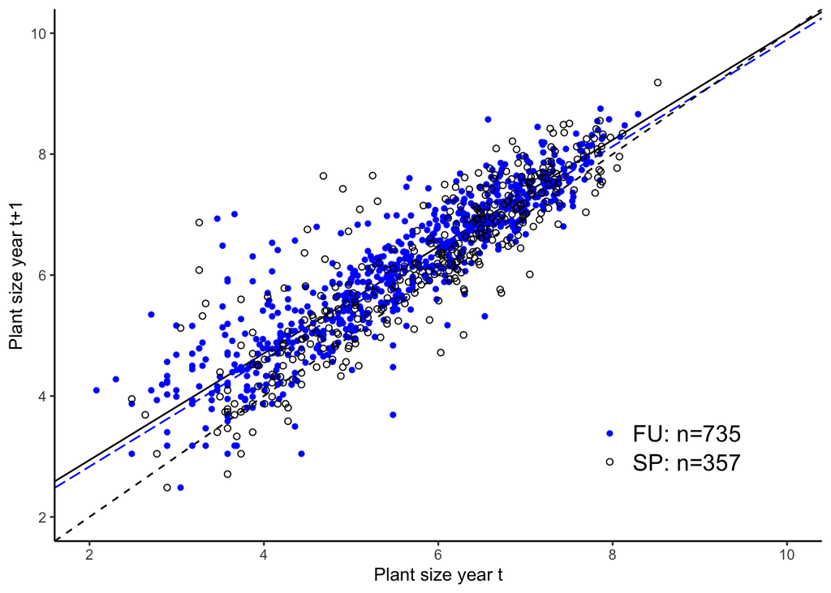

```r
FUcol <- "black"
SPcol <- "blue"

ggplot() +
  geom_abline(intercept = g.intercepts[1],slope = g.slopes[1], color=FUcol)+ # FU line
  geom_abline(intercept = g.intercepts[2],slope = g.slopes[2], linetype='longdash', color = SPcol)+ # SP line
  geom_abline(linetype='dashed') + # 45degree  line
  geom_point(data=growth_df,aes(x=size.t, y=size.t1, shape=site.s, color=site.s)) + # Size points for each site
  scale_shape_manual(name = "",values = c(16,1), labels = c("FU: n=735","SP: n=357")) +
  scale_color_manual(name = "",values = c(SPcol, FUcol), labels = c("FU: n=735","SP: n=357"))+
  theme_classic()+
  labs(x="Plant size year t", y="Plant size year t+1")+
  xlim(2,10)+
  ylim(2,10) +
  theme(legend.position = c(0.8, 0.2),
        legend.text = element_text(size=14))
```

#### Calculation: Flowering

```r
flower_df <- dataf_r1 %>%
  dplyr::select(flow.s = flow.all,
                site.s = site.all,
                size.t = size.t.all) %>%
  filter(complete.cases(.))

attach(flower_df)
# table(site.s)

store.size.flow=size.t[flow.s==1] # store size of plants that flowered
store.site.flow=site.s[flow.s==1] # store sites of plants that flowered

fit.flow.1=glm(flow.s~size.t*site.s, family=binomial) ## Fit flowering to binomial lm
fit.flow=glm(flow.s~size.t+site.s, family=binomial)
fit.flow.0=glm(flow.s~size.t, family=binomial)

anova(fit.flow.0,fit.flow,fit.flow.1, test="Chisq") ## Why test with Chisq here specifically?
```

```
## Analysis of Deviance Table
##
## Model 1: flow.s ~ size.t
## Model 2: flow.s ~ size.t + site.s
## Model 3: flow.s ~ size.t * site.s
##   Resid. Df Resid. Dev Df Deviance Pr(>Chi)
## 1      1156     186.69
## 2      1155     183.50  1   3.1860 0.074271 .
## 3      1154     175.04  1   8.4631 0.003624 **
## ---
## Signif. codes:  0 '***' 0.001 '**' 0.01 '*' 0.05 '.' 0.1 ' ' 1
```

```r
# Remove models from environments
rm(fit.flow,fit.flow.1,fit.flow.0)

fit.flow=glm(flow.s~site.s/size.t-1,family=binomial) ## Why '/'  and why -1?
f.intercepts=fit.flow$coef[1:2] ## Model intercepts
f.slopes=c(fit.flow$coef[3:4]) ## Model slopes

site.flow.SE=summary(fit.flow)$coef[5:6]
```

#### Plot: Flowering

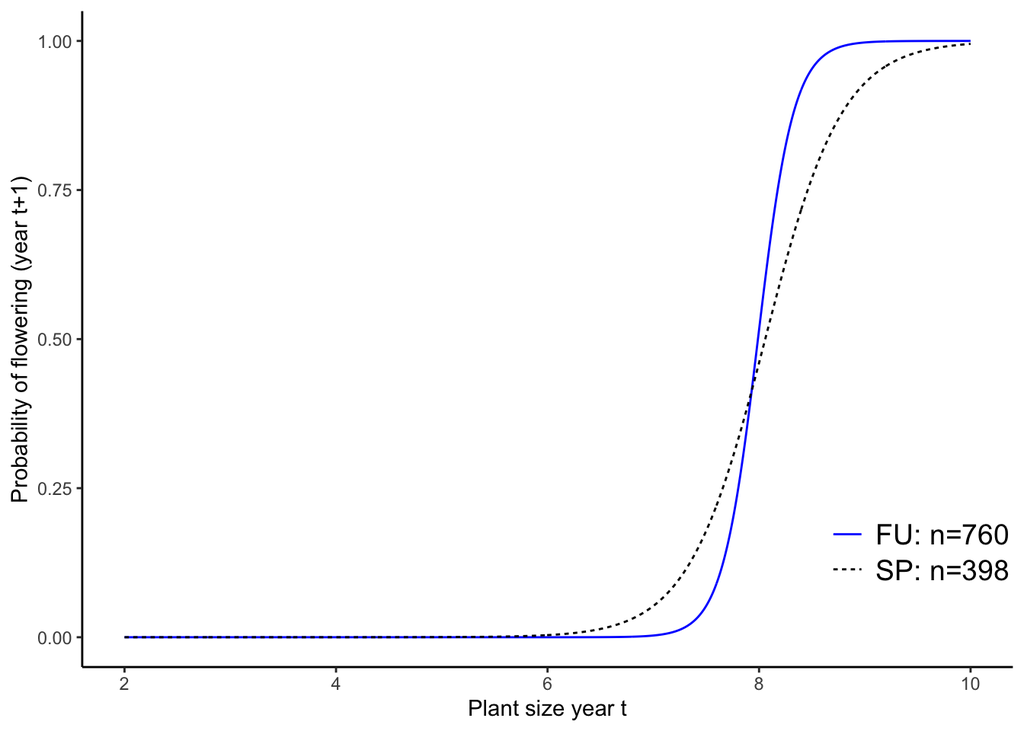

```r
flower_df$probability <- predict(fit.flow, site.s=flower_df$site.s, size.t = flower_df$size.t, type = "response")
predict_df <- data.frame(site.s=c(rep("FU",1000),rep("SP",1000)),
                         size.t=rep(seq(2,10,length.out = 1000),2))
predict_df <- cbind(predict_df,predict(fit.flow, newdata = predict_df, type = "response", se.fit = TRUE))


ggplot(data = predict_df, aes(x = size.t, y = fit)) +
  geom_line(aes(color = site.s, linetype=site.s)) +
  scale_color_manual(name = "", values=c(SPcol, FUcol),labels = c("FU: n=760","SP: n=398"))+
  scale_linetype_discrete(name = "",labels = c("FU: n=760","SP: n=398"))+
  scale_x_continuous(limits = c(2, 10)) +
  # geom_point(data=flower_df,aes(x=size.t,y=probability))+
  theme_classic()+
  labs(x="Plant size year t", y = "Probability of flowering (year t+1)")+
  theme(legend.position = c(0.9, 0.2),
        legend.text = element_text(size=14))
```

```r
### Don't understand where their points around the lines come from. Is that related to binning?
detach(flower_df)
```

#### Calculation: Survival

```r
survival_df <- dataf_r1 %>%
  dplyr::select(surv.s = surv.all,
                site.s = site.all,
                size.t = size.t.all) %>%
  filter(complete.cases(.))

attach(survival_df)
# table(site.s)

## 3 models to compare
fit.surv.1=glm(surv.s~size.t*site.s, family=binomial)
fit.surv=glm(surv.s~size.t+site.s, family=binomial)
fit.surv.0=glm(surv.s~size.t, family=binomial)

anova(fit.surv.0,fit.surv,fit.surv.1,test="Chisq")
```

```
## Analysis of Deviance Table
##
## Model 1: surv.s ~ size.t
## Model 2: surv.s ~ size.t + site.s
## Model 3: surv.s ~ size.t * site.s
##   Resid. Df Resid. Dev Df Deviance Pr(>Chi)
## 1      1224     505.42
## 2      1223     505.15  1   0.2647 0.606939
## 3      1222     492.80  1  12.3583 0.000439 ***
## ---
## Signif. codes:  0 '***' 0.001 '**' 0.01 '*' 0.05 '.' 0.1 ' ' 1
```

```r
rm(fit.surv.0,fit.surv,fit.surv.1)
fit.surv = glm(surv.s~site.s/size.t-1, family=binomial) ## Same as above -- why '/' and why -1?

s.intercepts = fit.surv$coef[1:2]
s.slopes = c(fit.surv$coef[3:4])
```

#### Plot: Survival

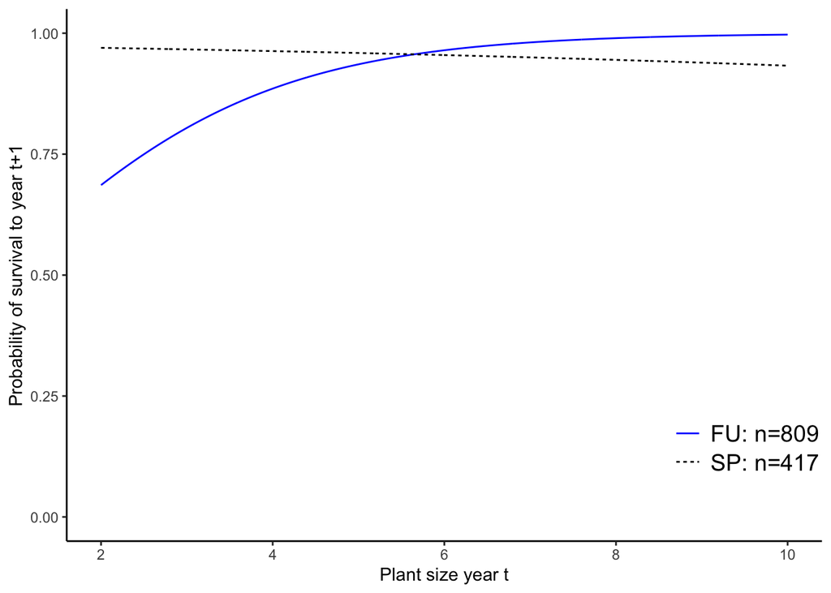

```r
survival_df$probability <- predict(fit.surv, site.s=site.s, size.t = size.t, type = "response")

predict_df <- data.frame(site.s=c(rep("FU",1000),rep("SP",1000)),
                         size.t=rep(seq(2,10,length.out = 1000),2))
predict_df <- cbind(predict_df,predict(fit.surv, newdata = predict_df, type = "response", se.fit = TRUE))

ggplot(data = predict_df, aes(x = size.t, y = fit)) +
  geom_line(aes(color = site.s, linetype=site.s)) +
  scale_color_manual(name = "", values=c(SPcol, FUcol),labels = c("FU: n=809","SP: n=417"))+
  scale_linetype_discrete(name = "",labels = c("FU: n=809","SP: n=417"))+
  scale_x_continuous(limits = c(2, 10)) +
  scale_y_continuous(limits = c(0,1))+
  # geom_point(data=flower_df,aes(x=size.t,y=probability))+
  theme_classic()+
  labs(x="Plant size year t", y = "Probability of survival to year t+1")+
  theme(legend.position = c(0.9, 0.2),
        legend.text = element_text(size=14))
```

```r
### Don't understand where their points around the lines come from. Is that related to binning?
detach(survival_df)
```

#### Calculation: Fecundity

```r
IPM.fecundity=data.frame(read.table("CT.IPM.fecundity.txt", header=T))
# names(IPM.fecundity)

# Unbrowsed individuals
fecundity_df <- IPM.fecundity %>%
  filter(brows.t1==0) %>%
  dplyr::select(size.t.f=size.t,
                site.t.f=site,
                si.t1.f=si.t1,
                nl.t.f=nl.t)

attach(fecundity_df)

fit.fec = lm(log(si.t1.f)~ ## dep var = log of seeds per individual (unbrowsed) in year t+1
               site.t.f + ## site of unbrowsed individuals
               size.t.f-1) ## size of unbrowsed Why -1? #
```

#### Plot: Fecundity

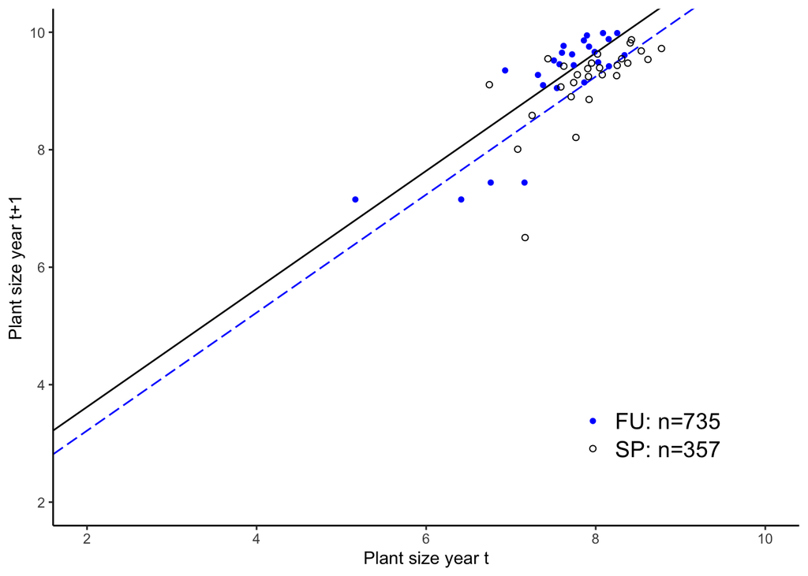

```r
ggplot() +
  geom_abline(intercept = fit.fec$coefficients[1],slope = fit.fec$coefficients[3], color=FUcol)+ # FU line
  geom_abline(intercept = fit.fec$coefficients[2],slope = fit.fec$coefficients[3], linetype='longdash', color = SPcol)+ # SP line
  geom_point(data=fecundity_df,aes(x=size.t.f, y=log(si.t1.f), shape=site.t.f, color=site.t.f)) + # Size points for each site
  scale_shape_manual(name = "",values = c(16,1), labels = c("FU: n=735","SP: n=357")) +
  scale_color_manual(name = "",values = c(SPcol, FUcol), labels = c("FU: n=735","SP: n=357"))+
  theme_classic()+
  labs(x="Plant size year t", y="Plant size year t+1")+
  xlim(2,10)+
  ylim(2,10) +
  theme(legend.position = c(0.8, 0.2),
        legend.text = element_text(size=14))
```

```r
detach(fecundity_df)
```

#### Seedling sizes

```r
####### Seedlings data #######
IPM.seedlings=data.frame(read.table("CT.IPM.seedlings.txt",header=T)) %>%
  filter(site != "JU") %>%
  dplyr::select(seedlings.size.t=size.t,
                seedlings.site=site)

fit.seedlings=lm(seedlings.size.t~seedlings.site-1, data = IPM.seedlings) ## That -1! What is that?
# summary(fit.seedlings)

## Add seedlings to all.sizes vector
size.all.plus.seedlings=c(all.sizes, IPM.seedlings$size.t[IPM.seedlings$year.t!=2003])
## Add site codes for seedlings to all sites vector
site.all.plus.seedlings=c(all.sizes, IPM.seedlings$site[IPM.seedlings$year.t!=2003])

####### Establishment data #######
IPM.establishment=data.frame(read.table("IPM.establishment.data.txt",header=T)) %>%
  dplyr::select(p.est.site=site,
                p.est.seeds.t=seeds.t,
                p.est.seedlings=sdl.t1)

attach(IPM.establishment)

## Site specific seedling establishment rates
est.p.est = IPM.establishment %>%
  group_by(p.est.site) %>%
  summarise(est_rate=sum(p.est.seedlings)/sum(p.est.seeds.t))
est.p.est = as.numeric(est.p.est$est_rate)

detach(IPM.establishment)
```

#### Collect parameters

```r
## Set upper and lower plant size bounds
minsize<-1
maxsize<-12

# Global variables for midpoint rule approximation
# n.big.matrix is the number of mesh points for size, n.age is the number of age classes.
n.big.matrix = 100; n.age = 50; n=n.big.matrix ## I think in paper they said 100 mesh points

L= minsize; U= maxsize;

# boundary points b and mesh points y
b = L+c(0:n)*(U-L)/n
y = 0.5*(b[1:n]+b[2:(n+1)])

# step size for midpoint rule, see equations 4 and 5
h = y[2]-y[1]

## initialize empty parameter matrix
store.p.vec = matrix(NA,12,2)
colnames(store.p.vec) <- c("FU","SP")
p.vec.names <- c("1st survival param","2nd survival param",
                  "1st flow param    ","2nd flow param    ",
                  "ag                ","bg                ",
                  "sigma2 growth     ","intercept seeds   ",
                  "slope seeds       ","mean kids size   ",
                  "sigma2 kids size ","growth variance parameter ")

## initialize empty parameter matrix
store.p.vec = matrix(NA,12,2)
colnames(store.p.vec) <- c("FU","SP")

## Store parameters in store.p.vec 12x2 array
for(i in 1:2){

    store.p.vec[1,i]<- as.numeric(s.intercepts[i])      # ; p.vec.names[1]<-"1st survival param";
    store.p.vec[2,i]<- s.slopes[i]              # ; p.vec.names[2]<-"2nd survival param";
    store.p.vec[3,i]<- f.intercepts[i]      #   ; p.vec.names[3]<-"1st flow param    ";
    store.p.vec[4,i]<- f.slopes[i]              # ; p.vec.names[4]<-"2nd flow param    ";
    store.p.vec[5,i]<- g.intercepts[i]      #   ; p.vec.names[5]<-"ag                ";
    store.p.vec[6,i]<- g.slopes[i]              # ; p.vec.names[6]<-"bg                ";
    store.p.vec[7,i]<- sigma.g^2                # ; p.vec.names[7]<-"sigma2 growth     ";
    store.p.vec[8,i]<- fit.fec$coef[i]   #          ; p.vec.names[8]<-"intercept seeds   ";
    store.p.vec[9,i]<- fit.fec$coef[3]   #      ; p.vec.names[9]<-"slope seeds       ";
    store.p.vec[10,i]<- fit.seedlings$coef[i]   #   ; p.vec.names[10]<-"mean kids size   ";
    store.p.vec[11,i]<- summary(fit.seedlings)$sigma^2  # ; p.vec.names[11]<-"sigma2 kids size ";
    store.p.vec[12,i]<- var.exp.coef[i]         # ; p.vec.names[12]<-"growth variance parameter ";

}
# summary(store.p.vec)
```

## Part II. Compute the kernel component functions from the fitted models

#### Basic demographic functions

```r
## Survival model

sx <- function(x,params) {
    u <- exp(params[2]*x+params[1]); ## Logit model => odds
    return(u/(1+u)); ## odds to prob
}

## Fecundity model
fx<-function(x,params) {
    u<-exp(params[3]+params[4]*x) ## Logit model => odds
      return(u/(1+u))  ## odds to prob
}

## Growth model
gxy<-function(x,y,params) {
    mux<-params[5]+params[6]*x; ## growth slope and intercepts
    sigmax2<-(params[7])*exp(2*(params[12]*mux)) ## Variance around growth curve
    sigmax<-sqrt(sigmax2); ## Standard deviation around growth curve
    fac1<-sqrt(2*pi)*sigmax; ## ??
    fac2<-((y-mux)^2)/(2*sigmax2); ## ??
    return(exp(-fac2)/fac1); ## ??
}

## Survival-growth function
pxy<-function(x,y,params) {
  return(sx(x,params)*(1-fx(x,params))*gxy(x,y,params))}

## Fecundity function
fxy<-function(x,y,params) {
    nkids<-p.est*exp(params[8]+params[9]*x) ## 8: seeds intercept; 9: seeds slope
    kidsize.mean<- params[10] ## Mean seedling size
    kidsize.var<- params[11] ## Sigma seedling size
    fac1<-sqrt(2*pi)*sqrt(kidsize.var) ## Same Q as 483 above
    fac2<-((y-kidsize.mean)^2)/(2*kidsize.var) ## 484 above
    f<-sx(x,params)*fx(x,params)*nkids*exp(-fac2)/fac1 ## End is 485 above
    return(f);
}
```

#### The ‘big matrix’ M of size n x n

```r
bigmatrix<-function(n,params) {

  # upper and lower integration limits
    L<-minsize; U<-maxsize;

  # boundary points b and mesh points y
    b<-L+c(0:n)*(U-L)/n; # Boundaries
    y<-0.5*(b[1:n]+b[2:(n+1)]); # Midpoints

  # construct the matrix
  I <- diag(n); ## Identity matrix

  ## Survival-growth matrix for all midpoint sizes
    P<-t(outer(y,y,pxy,params=params)) # P: survival-growth transpose outer product. Why transpose?

    ## fecundity matrix for all midpoint sizes
    B<-t(outer(y,y,fxy,params=params)) # B: fecundity

    ## Empty matrix of zeroes
    M=array(0,dim=c(2*n,2*n))

    ## Insert P matrix
    M[1:n,1:n]=P*(U-L)/n

    ## Insert B matrix to the right of the P matrix
    M[1:n,(n+1):(2*n)]=B*(U-L)/n

    ## Insert the identity matrix
    M[(n+1):(2*n),1:n]=diag(n)
    K<-M ## Call K to match paper?
  P<-(U-L)*P/n
  B<-(U-L)*B/n
    return(list(matrix=M,
                kernel=K,
                meshpts=y,
                Pmatrix=P,
                Bmatrix=B,
                Imatrix=I));
}


R0.calc<-function(n,params){

  M<-bigmatrix(n,params) ## Construct matrix

  ## If any NAs in matrix, return NA for estimates
    if (any(is.na(M$matrix))){
        ave.R0=NA
        lam=NA
        T=NA }

  else{
        N <- solve(M$Imatrix-M$Pmatrix) ## ??
        R <- M$Bmatrix %*% N ## Matrix multiplication
        ave.R0<-Re(eigen(R)$values[1]) ##
        lam<-Re(eigen(M$matrix)$values[1]);
        T=log(ave.R0)/log(lam)
    }

    return(list(lam=lam,ave.R0=ave.R0,T=T))
}

R0.betas<-function(x){

    p.vec[3] <- x;
    nR0 <- R0.calc(n.big.matrix, p.vec)
    return(nR0$ave.R0)

}
```

#### Calculation: generation time

```r
gen.time=rep(NA,2)

for(i in 1:2){
    #if(i==1) p.est= 8.604605e-05 else p.est=0.0001655622  # assuming dd-reg
    if(i==1) p.est= est.p.est[1] else p.est=est.p.est[2]   # actual
    p.vec=store.p.vec[,i]
    tmp=R0.calc(n.big.matrix,p.vec)
    gen.time[i]=tmp$T
    cat("Site ",i," lambda=",tmp$lam," R0=",tmp$ave.R0," Generation time=",tmp$T,"\n")
    cat("ESS intercept ", optimize(R0.betas, c(-100,10), maximum=T, tol=0.01)$maximum,"\n")
}
```

```
## Site  1  lambda= 1.048766  R0= 1.675448  Generation time= 10.83887
## ESS intercept  -64.51811
## Site  2  lambda= 1.167493  R0= 4.989201  Generation time= 10.37898
## ESS intercept  -26.50841
```

#### Calculation: Evolutionarily stable strategy

```r
n.test <- 100
R0.beta <- array(NA,dim=c(n.test,2));
lam.beta <- array(NA,dim=c(n.test,2));
ESS = rep(NA,2)
```

#### Plot: Evolutionarily stable strategy

```r
dev.new()
par(mfrow=c(2,2), mar=c(3,3,1,2)+0.1, bty="l",pty="s", cex.main=1, cex.axis=1, cex.lab=1, tck=0.02, mgp=c(2, 0.3 ,0)) ;

for(i in 1:2){
    p.vec=store.p.vec[,i]
    #if(i==1) p.est= 8.604605e-05 else p.est=0.0001655622  # assuming dd-reg
    if(i==1) p.est= est.p.est[1] else p.est=est.p.est[2]   # actual
    if(i==1) beta.flow<-seq(-100,0,length=n.test) else beta.flow<-seq(-50,0,length=n.test);

    for(beta.test in 1:n.test){
        p.vec[3]<-beta.flow[beta.test];
        nR0<-R0.calc(n.big.matrix,p.vec)
        R0.beta[beta.test,i]<-nR0$ave.R0
        lam.beta[beta.test,i]<-nR0$lam
        cat(beta.flow[beta.test],"  ",nR0$ave.R0,"  ",nR0$lam,"\n")
    }

    ESS[i]<-beta.flow[R0.beta[,i]==max(R0.beta[,i])]

    plot(beta.flow,R0.beta[,i],type="n",xlab=expression("Intercept of flowering function " * italic(beta * scriptstyle(0))),
    ylab=expression(italic("R"*scriptstyle(0))))
    min.R0=min(R0.beta[,i]); max.R0=max(R0.beta[,i])
    mean.m2se=fit.flow$coef[i]-2*site.flow.SE[i]
    mean.p2se=fit.flow$coef[i]+2*site.flow.SE[i]

    polygon(c(mean.m2se,mean.p2se,mean.p2se,mean.m2se),c(min.R0,min.R0,max.R0,max.R0), col="grey90",border=0)
    points(beta.flow,R0.beta[,i],type="l")
    abline(h=1)
    points(beta.flow[R0.beta[,i]==max(R0.beta[,i])],max(R0.beta[,i]),pch=19)
    abline(v=fit.flow$coef[i])
    #abline(v=beta.flow[R0.beta==max(R0.beta)])

    # if (i==1) text(2.3,10,"a)") else text(locator(1),"c)")

    plot(beta.flow,lam.beta[,i],type="n",xlab=expression("Intercept of flowering function " * italic(beta * scriptstyle(0))),
    ylab=expression(italic(lambda)))
    min.R0=min(lam.beta[,i]);max.R0=max(lam.beta[,i])
    mean.m2se=fit.flow$coef[i]-2*site.flow.SE[i]
    mean.p2se=fit.flow$coef[i]+2*site.flow.SE[i]

    polygon(c(mean.m2se,mean.p2se,mean.p2se,mean.m2se),c(min.R0,min.R0,max.R0,max.R0), col="grey90",border=0)
    points(beta.flow,lam.beta[,i],type="l")
    abline(h=1)
    abline(v=fit.flow$coef[i])
    points(beta.flow[lam.beta[,i]==max(lam.beta[,i])],max(lam.beta[,i]),pch=19)

    # if (i==1) text(locator(1),"b)") else text(locator(1),"d)")
}
```

```
## -100    1.16473e-13    0.997046
## -98.9899    3.198206e-13    0.997046
## -97.9798    8.781885e-13    0.997046
## -96.9697    2.411399e-12    0.997046
## -95.9596    6.621408e-12    0.997046
## -94.94949    1.818158e-11    0.997046
## -93.93939    4.992441e-11    0.997046
## -92.92929    1.370863e-10    0.997046
## -91.91919    3.764224e-10    0.997046
## -90.90909    1.03361e-09    0.997046
## -89.89899    2.838168e-09    0.997046
## -88.88889    7.793264e-09    0.997046
## -87.87879    2.139935e-08    0.997046
## -86.86869    5.876003e-08    0.997046
## -85.85859    1.613479e-07    0.997046
## -84.84848    4.430416e-07    0.997046
## -83.83838    1.216538e-06    0.997046
## -82.82828    3.340466e-06    0.997046
## -81.81818    9.17251e-06    0.997046
## -80.80808    2.518657e-05    0.9970461
## -79.79798    6.915904e-05    0.9970462
## -78.78788    0.0001899007    0.9970466
## -77.77778    0.0005214323    0.9970476
## -76.76768    0.001431699    0.9970505
## -75.75758    0.00393059    0.9970582
## -74.74747    0.01078779    0.9970795
## -73.73737    0.0295833    0.9971377
## -72.72727    0.08094238    0.9972961
## -71.71717    0.2201064    0.9977209
## -70.70707    0.5888089    0.998818
## -69.69697    1.510893    1.001419
## -68.68687    3.52426    1.006689
## -67.67677    6.878034    1.01531
## -66.66667    10.54698    1.026729
## -65.65657    12.95905    1.03955
## -64.64646    13.74729    1.052374
## -63.63636    13.4378    1.064228
## -62.62626    12.56721    1.074592
## -61.61616    11.46166    1.083272
## -60.60606    10.29432    1.090246
```

[output cut: 45 more lines]

```
## -14.14141    0.02932314    0.2414292
## -13.13131    0.02850853    0.21787
## -12.12121    0.02797379    0.1979538
## -11.11111    0.02763632    0.18319
## -10.10101    0.02743164    0.1740208
## -9.090909    0.02731238    0.169147
## -8.080808    0.02724569    0.1667808
## -7.070707    0.02721006    0.1656847
## -6.060606    0.02719211    0.1651964
## -5.050505    0.0271838    0.1649898
## -4.040404    0.0271803    0.1649075
## -3.030303    0.02717894    0.1648762
## -2.020202    0.02717843    0.1648646
## -1.010101    0.02717824    0.1648604
## 0    0.02717817    0.1648588
```

```
## -50    1.48195e-08    0.9385119
## -49.49495    2.455693e-08    0.9385119
## -48.9899    4.069254e-08    0.9385119
## -48.48485    6.743035e-08    0.9385119
## -47.9798    1.117368e-07    0.938512
## -47.47475    1.851555e-07    0.938512
## -46.9697    3.068155e-07    0.938512
## -46.46465    5.084146e-07    0.9385121
## -45.9596    8.424781e-07    0.9385121
## -45.45455    1.396044e-06    0.9385123
## -44.94949    2.313342e-06    0.9385125
## -44.44444    3.833367e-06    0.9385129
## -43.93939    6.352151e-06    0.9385136
## -43.43434    1.052595e-05    0.9385147
## -42.92929    1.74422e-05    0.9385165
## -42.42424    2.890289e-05    0.9385196
## -41.91919    4.789394e-05    0.9385246
## -41.41414    7.936319e-05    0.9385329
## -40.90909    0.0001315092    0.9385467
## -40.40404    0.0002179169    0.9385695
## -39.89899    0.0003610954    0.9386072
## -39.39394    0.0005983378    0.9386696
## -38.88889    0.0009914262    0.9387724
## -38.38384    0.001642694    0.9389415
## -37.87879    0.002721599    0.9392182
## -37.37374    0.004508618    0.9396674
## -36.86869    0.007467635    0.9403878
## -36.36364    0.01236491    0.9415222
## -35.85859    0.02046359    0.9432617
## -35.35354    0.03383874    0.9458367
## -34.84848    0.05588025    0.9494867
## -34.34343    0.09207507    0.9544165
## -33.83838    0.1511721    0.9607581
## -33.33333    0.2467858    0.9685545
## -32.82828    0.3992911    0.9777649
## -32.32323    0.6373335    0.9882781
## -31.81818    0.9973315    0.9999254
## -31.31313    1.518324    1.01249
## -30.80808    2.229837    1.025722
## -30.30303    3.134172    1.039348
```

[output cut: 45 more lines]

```
## -7.070707    0.1966176    0.4750001
## -6.565657    0.1929948    0.4598438
## -6.060606    0.190525    0.4493551
## -5.555556    0.188875    0.4424759
## -5.050505    0.1877929    0.4381176
## -4.545455    0.187095    0.4354125
## -4.040404    0.1866515    0.4337531
## -3.535354    0.186373    0.4327424
## -3.030303    0.1862    0.4321293
## -2.525253    0.1860935    0.4317583
## -2.020202    0.1860282    0.4315342
## -1.515152    0.1859884    0.4313989
## -1.010101    0.1859643    0.4313172
## -0.5050505    0.1859497    0.4312679
## 0    0.1859408    0.4312381
```

#### Constructing the component matrices and their transposes

```r
# Put all component matrices into 3-dimensional arrays
P <- array(NA,dim=c(n.big.matrix,n.big.matrix)) #P[j,i,a] will be h*P_{a-1}(x_j,x_i)
B <- array(NA,dim=c(n.big.matrix,n.big.matrix)) #B[j,i,a] will be h*F_{a-1}(x_j,x_i)

stable.dist=array(NA,dim=c(n,n.age,2))
lam.stable.age=rep(NA,2);

for(i in 1:2){
    p.vec=store.p.vec[,i]
    if(i==1) p.est=est.p.est[1] else p.est=est.p.est[2]
    P<-h*t(outer(y,y,pxy,params=p.vec))
    B<-h*t(outer(y,y,fxy,params=p.vec))

#============================================================================================#
#   Model iteration functions
#============================================================================================#

    # population now and next year
    Nt=matrix(0,n.big.matrix,n.age);
    Nt1=Nt
    Nt2=Nt

    iteration=function(Nt1,Nt){
        for(age in 2:n.age){
            Nt2[,age]=P%*%Nt1[,age-1]
            }
        Nt2[,1]=0;

        for(age in 1:n.age){
            Nt2[,1]=Nt2[,1]+B%*%Nt[,age]
            }
        return(Nt2)
        }

  #============================================================================================#
  # Start using the model
  #============================================================================================#

  # Estimate lambda and w by iterating unperturbed matrix
    Nt1=matrix(1,n.big.matrix,n.age);
    Nt=Nt1
    qmax=1000;
    lam=1;
    tol=1.e-8;
    while(qmax>tol) {
        Nt2=iteration(Nt1,Nt);
        qmax=sum(abs(Nt2-lam*Nt1));
        lam=sum(Nt2)/sum(Nt1);

        Nt=Nt1
        Nt1=Nt2

        tot=sum(Nt1+Nt2)

        Nt=Nt/tot
        Nt1=Nt1/tot

        cat(lam,qmax,"\n");
    }

    stable.dist[,,i]=Nt/sum(Nt); lam.stable.age[i]=lam;

}
```

```
## 13.10921 65390.92
## 1.782144 6.443682
## 0.8532779 0.853326
## 0.9019406 0.4638502
## 0.9322872 0.4690996
## 0.947794 0.4705897
## 0.9632477 0.4740592
## 1.003417 0.4810223
## 1.070745 0.4702969
## 1.126989 0.4238015
## 1.139101 0.316531
## 1.114777 0.237085
## 1.07756 0.1932876
## 1.043481 0.1638186
## 1.019821 0.1393329
## 1.009401 0.1149309
## 1.012472 0.09301079
## 1.026331 0.08650453
## 1.045044 0.08517669
## 1.061324 0.08074008
## 1.069947 0.07018763
## 1.069803 0.05377798
## 1.063193 0.04651208
## 1.053809 0.04348423
## 1.045093 0.04060368
## 1.039412 0.0359911
## 1.037784 0.02940216
## 1.039884 0.02478934
## 1.044328 0.02328394
## 1.049235 0.0223247
## 1.052936 0.02035471
## 1.054513 0.01692887
## 1.053949 0.01344377
## 1.051912 0.01211758
## 1.049365 0.0114507
## 1.047198 0.01062042
## 1.045986 0.009294319
## 1.045895 0.007333126
## 1.046713 0.006404357
## 1.047992 0.006082099
```

[output cut: 176 more lines]

```
## 1.167493 2.273163e-07
## 1.167493 1.899714e-07
## 1.167493 1.584221e-07
## 1.167493 1.23891e-07
## 1.167493 8.806228e-08
## 1.167493 6.881345e-08
## 1.167493 5.842725e-08
## 1.167493 4.867722e-08
## 1.167493 3.749347e-08
## 1.167493 2.688771e-08
## 1.167493 2.155742e-08
## 1.167493 1.793847e-08
## 1.167493 1.482559e-08
## 1.167493 1.124708e-08
## 1.167493 8.248694e-09
```

#### Calculation: Stable distribution and size-dependent total elasticity

```r
stable.dist.flow=stable.dist

p.surv.flow=sx(y,p.vec)*fx(y,p.vec)

for(i in 1:2){
    for(age in 1:n.age){
        stable.dist.flow[,age,i]=stable.dist[,age,i]*p.surv.flow
    }
}

for(i in 1:2){
    stable.dist.flow[,,i]=stable.dist.flow[,,i]/(sum(stable.dist.flow[,,i]))
}

dataf=data.frame(read.table("ipm.saf.data.txt",header=T))
attach(dataf)
flow.age=age.05[flo.05==1]
flow.site=as.numeric(site[flo.05==1])
age=age.05
site=as.numeric(site)

stable.dist.age=array(NA,dim=c(n.age,2))
stable.dist.age.flow=array(NA,dim=c(n.age,2))
```

##### Plot: Stable age distribution (see Fig. 2)

```r
dev.new()
par(mfrow=c(2,2), mar=c(3,3,1,2)+0.1, bty="l",pty="s", cex.main=1, cex.axis=1, cex.lab=1, tck=0.02, mgp=c(2, 0.3 ,0)) ;

for(i in 1:2){
    hist(age[site==i],breaks=seq(0,50,3),freq=F,col="grey",main="",xlab="Age (years)", ylim=c(0,0.2))
    stable.dist.age[,i]=apply(stable.dist[,,i],2,sum)
    points(0:(n.age-1),stable.dist.age[,i],type="l")
    # if (i==1) text(locator(1),"a)") else text(locator(1),"c)")

    hist(flow.age[flow.site==i],breaks=seq(0,50,3),freq=F,col="grey",main="",xlab="Age (years)",ylim=c(0,0.20))
    stable.dist.age.flow[,i]=apply(stable.dist.flow[,,i],2,sum)
    points(0:(n.age-1),stable.dist.age.flow[,i],type="l")
    # if (i==1) text(locator(1),"b)") else text(locator(1),"d)")
}

mean.age.f=rep(NA,2)
mean.size.f=rep(NA,2)

for(i in 1:2){
    mean.age.f[i] <-sum((1:(n.age))*apply(stable.dist.flow[,,i],2,sum))-1;
    cat("Mean flowering age",mean.age.f[i],"\n")
    mean.size.f[i]<-sum(exp(y)*apply(stable.dist.flow[,,i],1,sum));
    cat("Mean flowering size",mean.size.f[i],"\n")
}
```

```
## Mean flowering age 8.016105
## Mean flowering size 2990.466
## Mean flowering age 6.957204
## Mean flowering size 2849.351
```

```r
stable.dist.size=array(NA,dim=c(n.big.matrix,2))
stable.dist.size.flow=array(NA,dim=c(n.big.matrix,2))
```

#### Stable size distribution (see Fig. 3)

```r
dev.new()
par(mfrow=c(2,2), mar=c(3,3,1,2)+0.1, bty="l",pty="s", cex.main=1, cex.axis=1, cex.lab=1, tck=0.02, mgp=c(2, 0.3 ,0)) ;

for(i in 1:2){
    hist(size.all.plus.seedlings[site.all.plus.seedlings==i],freq=T,col="grey",main="",xlab="Plant size",breaks=seq(1,10.5,0.5))
    stable.dist.size[,i]=sum(!is.na(size.all.plus.seedlings[site.all.plus.seedlings==i]))*apply(stable.dist[,,i],1,sum)/(y[2]-y[1])/2
    points(y,stable.dist.size[,i],type="l")
    # if (i==1) text(locator(1),"a)") else text(locator(1),"c)")

    hist(store.size.flow[store.site.flow==site.code.l[i]],freq=T,col="grey",main="",xlab="Plant size",breaks=seq(2,9.5,0.5))
    stable.dist.size.flow[,i]=sum(!is.na(store.size.flow[store.site.flow==site.code.l[i]]))*apply(stable.dist.flow[,,i],1,sum)/(y[2]-y[1])/2
    points(y,stable.dist.size.flow[,i],type="l")
    # if (i==1) text(locator(1),"b)") else text(locator(1),"d)")
}
```

#### Iterate model with time lag

```r
stable.dist.tl=array(0,dim=c(n,2))
lam.stable.tl=rep(NA,2)
b = L+c(0:n)*(U-L)/n; y = 0.5*(b[1:n]+b[2:(n+1)]);
h = y[2]-y[1]

for(i in 1:2){
    p.vec=store.p.vec[,i]
    if(i==1) p.est= est.p.est[1] else p.est=est.p.est[2]
    P<-h*t(outer(y,y,pxy,params=p.vec))
    B<-h*t(outer(y,y,fxy,params=p.vec))

    qmax=1000

    # population now, next year and the one after
    Nt=matrix(1/n,n);
    Nt1=Nt/2;

    while(qmax>1e-10) {
        Nt2=P%*%Nt1+B%*%Nt
        qmax=sum(abs(Nt2-lam*Nt1));
        lam=sum(Nt2)/sum(Nt1);
        Nt=Nt1;
        Nt1=Nt2;
        tot=sum(Nt+Nt1)
        Nt=Nt/tot
        Nt1=Nt1/tot
    }
    stable.dist.tl[,i]=Nt/sum(Nt); lam.stable.tl[i]=lam;
}

lam.stable.age
```

```
## [1] 1.048766 1.167493
```

```r
lam.stable.tl
```

```
## [1] 1.048766 1.167493
```

#### Calculation: sensitivity and elasticity by perturbation P matrix

```r
sen.big.P<-array(NA,dim=c(n,n))     #array to store the results
elas.big.P<-array(NA,dim=c(n,n,2))

for(i in 1:2){
    p.vec=store.p.vec[,i]
    if(i==1) p.est= est.p.est[1] else p.est=est.p.est[2]               #actual

    P<-h*t(outer(y,y,pxy,params=p.vec))
    B<-h*t(outer(y,y,fxy,params=p.vec))


    for(row in 1:n) {       # loop over y values
        # choose x* to maximize e(y,x) for this y value, by scanning across the row
        big.one=which(P[row,]*stable.dist.tl[,i]==max(P[row,]*stable.dist.tl[,i]));

        # perturb the kernel up and down near (y,x*)
        delta=0.1*h*P[row,big.one];
        Pup=P; Pup[row,big.one] = P[row,big.one]+delta/h;
        Pdown=P; Pdown[row,big.one] = P[row,big.one]-delta/h;

        qmax=1; lamup=1; lamdown=1;
        Nt.up<-stable.dist.tl[,i]; Nt1.up<-stable.dist.tl[,i]
        Nt.down<-stable.dist.tl[,i]; Nt1.down<-stable.dist.tl[,i]

        while(qmax>1e-10) {
            Nt2.up=Pup%*%Nt1.up+B%*%Nt.up
            qmax=sum(abs(Nt2.up-lamup*Nt1.up));
            lamup=sum(Nt2.up)/sum(Nt1.up);

            Nt.up=Nt1.up;
            Nt1.up=Nt2.up;
            tot=sum(Nt.up+Nt1.up)
            Nt.up=Nt.up/tot
            Nt1.up=Nt1.up/tot

            Nt2.down=Pdown%*%Nt1.down+B%*%Nt.down

            qmax=qmax+sum(abs(Nt2.down-lamdown*Nt1.down));
            lamdown=sum(Nt2.down)/sum(Nt1.down);

            Nt.down=Nt1.down;
            Nt1.down=Nt2.down;
            tot=sum(Nt.down+Nt1.down)
            Nt.down=Nt.down/tot
            Nt1.down=Nt1.down/tot

            #cat(lamup,lamdown,qmax,"\n");
        }


        sen.big.row<-(lamup-lamdown)/(2*delta) #sensitivity for perturbation at (y,x*)
        sen.big.P[row,]<-(stable.dist.tl[,i]/stable.dist.tl[,i][big.one])*sen.big.row #sensitivity at other x's
        cat(row,big.one,lamup,lamdown," sens=",sen.big.row, "\n")
    }

    elas.big.P[,,i]=(P/h)*sen.big.P/lam.stable.tl[i];

}
```

```
## 1 10 1.048766 1.048765  sens= 0.005454862
## 2 11 1.048766 1.048765  sens= 0.007311486
## 3 11 1.048766 1.048765  sens= 0.007888722
## 4 11 1.048766 1.048765  sens= 0.008491295
## 5 12 1.048767 1.048765  sens= 0.01112822
## 6 12 1.048767 1.048764  sens= 0.01191879
## 7 13 1.048767 1.048764  sens= 0.01529594
## 8 13 1.048768 1.048764  sens= 0.01629973
## 9 14 1.048768 1.048763  sens= 0.02047714
## 10 14 1.048769 1.048763  sens= 0.02171342
## 11 15 1.048769 1.048762  sens= 0.02670417
## 12 15 1.04877 1.048761  sens= 0.02818576
## 13 16 1.048771 1.04876  sens= 0.03394624
## 14 16 1.048773 1.048758  sens= 0.03567942
## 15 16 1.048774 1.048757  sens= 0.03742866
```

[output cut: 185 more lines]

```r
sum(elas.big.P[,,1]*h*h)
```

```
## [1] 0.81223
```

```r
sum(elas.big.P[,,2]*h*h)
```

```
## [1] 0.7876917
```

#### Calculation: sensitivity and elasticity by perturbation B matrix

```r
sen.big.B<-array(NA,dim=c(n,n))     #array to store the results
elas.big.B<-array(NA,dim=c(n,n,2))

for(i in 1:2){
    p.vec=store.p.vec[,i]
    if(i==1) p.est= est.p.est[1] else p.est=est.p.est[2]               #actual

    P<-h*t(outer(y,y,pxy,params=p.vec))
    B<-h*t(outer(y,y,fxy,params=p.vec))

    for(row in 1:n) {       # loop over y values
        # choose x* to maximize e(y,x) for this y value, by scanning across the row
        big.one=which(B[row,]*stable.dist.tl[,i]==max(B[row,]*stable.dist.tl[,i]));

        # perturb the kernel up and down near (y,x*)
        delta=0.1*h*B[row,big.one];
        Bup=B; Bup[row,big.one] = B[row,big.one]+delta/h;
        Bdown=B; Bdown[row,big.one] = B[row,big.one]-delta/h;

        qmax=1;
        lamup=1;
        lamdown=1;

        Nt.up<-stable.dist.tl[,i];
        Nt1.up<-stable.dist.tl[,i]

        Nt.down<-stable.dist.tl[,i];
        Nt1.down<-stable.dist.tl[,i]

        while(qmax>1e-10) {
            Nt2.up=P%*%Nt1.up+Bup%*%Nt.up
            qmax=sum(abs(Nt2.up-lamup*Nt1.up));
            lamup=sum(Nt2.up)/sum(Nt1.up);

            Nt.up=Nt1.up;
            Nt1.up=Nt2.up;
            tot=sum(Nt.up+Nt1.up)
            Nt.up=Nt.up/tot
            Nt1.up=Nt1.up/tot

            Nt2.down=P%*%Nt1.down+Bdown%*%Nt.down

            qmax=qmax+sum(abs(Nt2.down-lamdown*Nt1.down));
            lamdown=sum(Nt2.down)/sum(Nt1.down);

            Nt.down=Nt1.down;
            Nt1.down=Nt2.down;
            tot=sum(Nt.down+Nt1.down)
            Nt.down=Nt.down/tot
            Nt1.down=Nt1.down/tot

            #cat(lamup,lamdown,qmax,"\n");
        }

        sen.big.row<-(lamup-lamdown)/(2*delta) #sensitivity for perturbation at (y,x*)
        sen.big.B[row,]<-(stable.dist.tl[,i]/stable.dist.tl[,i][big.one])*sen.big.row #sensitivity at other x's
        cat(row,big.one," sens=",sen.big.row, "\n")
    }

    elas.big.B[,,i]=2*(B/h)*sen.big.B/lam.stable.tl[i];

}
```

```
## 1 66  sens= 0.01658482
## 2 66  sens= 0.01793492
## 3 66  sens= 0.01935087
## 4 66  sens= 0.02082897
## 5 66  sens= 0.02236486
## 6 66  sens= 0.02395371
## 7 66  sens= 0.0255904
## 8 66  sens= 0.02726976
## 9 66  sens= 0.02898679
## 10 66  sens= 0.03073683
## 11 66  sens= 0.03251568
## 12 66  sens= 0.0343197
## 13 66  sens= 0.03614579
## 14 66  sens= 0.03799128
## 15 66  sens= 0.03985386
```

[output cut: 185 more lines]

```r
sum(elas.big.B[,,1]*h*h)+sum(elas.big.P[,,1]*h*h)
```

```
## [1] 1.000001
```

```r
sum(elas.big.B[,,2]*h*h)+sum(elas.big.P[,,2]*h*h)
```

```
## [1] 1
```

#### Plot: elasticity (see Fig 5)

```r
dev.new()
par(mfrow=c(2,2), mar=c(3,3,1,2)+0.1, bty="l",pty="s", cex.main=1, cex.axis=1, cex.lab=1, tck=0.02, mgp=c(2, 0.3 ,0)) ;

zmax=max(elas.big.P,elas.big.B)

image(y,y,t(elas.big.P[,,1]),xlab="Plant size year t",ylab="Plant size year t+1",col=grey(1:300/300),gamma=0.2,zlim=c(0,1.1*zmax));
    contour(y,y,t(elas.big.P[,,1]),add=T,cex=3,levels = c(0.01,0.05,0.1,0.15,0.2,0.25,0.3));
    # text(locator(1),"a)",col="white")

image(y,y,t(elas.big.B[,,1]),xlab="Plant size year t-1",ylab="Plant size year t+1",col=grey(1:300/300),gamma=0.2,zlim=c(0,1.1*zmax));
    contour(y,y,t(elas.big.B[,,1]),add=T,cex=3,levels = c(0.01,0.05,0.1,0.15,0.2,0.25,0.3));
    # text(locator(1),"b)",col="white")

image(y,y,t(elas.big.P[,,2]),xlab="Plant size year t",ylab="Plant size year t+1",col=grey(1:300/300),gamma=0.2,zlim=c(0,1.1*zmax));
    contour(y,y,t(elas.big.P[,,2]),add=T,cex=3,levels = c(0.01,0.05,0.1,0.15,0.2,0.25,0.3));
    # text(locator(1),"c)",col="white")

image(y,y,t(elas.big.B[,,2]),xlab="Plant size year t-1",ylab="Plant size year t+1",col=grey(1:300/300),gamma=0.2,zlim=c(0,1.1*zmax));
    contour(y,y,t(elas.big.B[,,2]),add=T,cex=3,levels = c(0.01,0.05,0.1,0.15,0.2,0.25,0.3));
    # text(locator(1),"d)",col="white")
```

#### Calculation: new big matrix approximation

```r
M.tl=array(0,dim=c(2*n,2*n))
lam.stable.bm=rep(NA,2)
R0.stable.bm=rep(NA,2)

for(i in 1:2){
    p.vec=store.p.vec[,i]
    if(i==1) p.est= est.p.est[1] else p.est=est.p.est[2]
    if(i==1) p.vec[3]=-58.67228 else p.vec[3]= -26.25266

    P<-h*t(outer(y,y,pxy,params=p.vec))
    B<-h*t(outer(y,y,fxy,params=p.vec))

    M.tl[1:n,1:n]=P
    M.tl[1:n,(n+1):(2*n)]=B
    M.tl[(n+1):(2*n),1:n]=diag(n)

    lam.stable.bm[i]=Re(eigen(M.tl)$values[1]);

    #R0
    M.P=array(0,dim=c(2*n,2*n))
    M.B=array(0,dim=c(2*n,2*n))

    M.P[1:n,1:n]=P
    M.P[(n+1):(2*n),1:n]=diag(n)

    M.B[1:n,(n+1):(2*n)]=B


    N<-solve(diag(2*n)-M.P);
    R<- M.B %*% N
    R0.stable.bm[i]<-Re(eigen(R)$values[1]);

    # Generation time
    T.stable.mb <-log(R0.stable.bm)/log(lam.stable.bm)
}


lam.stable.bm   # Lambda
```

```
## [1] 1.099069 1.135874
```

```r
R0.stable.bm    # Net reproductive rate
```

```
## [1] 8.171492 8.794975
```

```r
T.stable.mb     # Generation time
```

```
## [1] 22.23775 17.06543
```

#### Simulate Lambda, R0 and T with varying p.est

```r
seq.start <- 0.00001
seq.end <- 0.001
seq.by <- 0.00001
p.est.seq <- seq(seq.start,seq.end,by=seq.by)
n.p.est <- length(p.est.seq)

p.est.FU <- 0.00016
p.est.SP <- 0.00078

Res.p.est <- matrix(0,n.p.est,8)
dimnames(Res.p.est) <- list(1:n.p.est,c("p.est","p.est","l.FU","l.SP","Ro.FU","Ro.SP","T.FU","T.SP"))

#new big matrix approximation
M.tl=array(0,dim=c(2*n,2*n))
lam.stable.bm=rep(NA,2)
R0.stable.bm=rep(NA,2)

for (k in 1:n.p.est){
    for(i in 1:2){
        p.est= p.est.seq[k]
        p.vec=store.p.vec[,i]
        P<-h*t(outer(y,y,pxy,params=p.vec))
        B<-h*t(outer(y,y,fxy,params=p.vec))
        M.tl[1:n,1:n]=P
        M.tl[1:n,(n+1):(2*n)]=B
        M.tl[(n+1):(2*n),1:n]=diag(n)
        lam.stable.bm=Re(eigen(M.tl)$values[1]);

    # R0
        M.P=array(0,dim=c(2*n,2*n))
        M.B=array(0,dim=c(2*n,2*n))
        M.P[1:n,1:n]=P
        M.P[(n+1):(2*n),1:n]=diag(n)
        M.B[1:n,(n+1):(2*n)]=B
        N<-solve(diag(2*n)-M.P);
        R<- M.B %*% N
        R0.stable.bm<-Re(eigen(R)$values[1]);

    # Generation time
        T.stable.bm <-log(R0.stable.bm)/log(lam.stable.bm)

    # Filling in of result matrix
        Res.p.est[k,i] <- p.est
        Res.p.est[k,i+2] <- lam.stable.bm
        Res.p.est[k,i+4] <- R0.stable.bm
        Res.p.est[k,i+6] <- T.stable.bm
    }
}

Res.p.est
```

```
##       p.est   p.est      l.FU      l.SP      Ro.FU      Ro.SP     T.FU
## 1   0.00001 0.00001 0.8263343 0.8244452  0.1018270 0.06432277 11.97593
## 2   0.00002 0.00002 0.8725686 0.8584002  0.2036540 0.12864554 11.67403
## 3   0.00003 0.00003 0.9020529 0.8812231  0.3054810 0.19296832 11.50411
## 4   0.00004 0.00004 0.9241485 0.8988413  0.4073080 0.25729109 11.38638
## 5   0.00005 0.00005 0.9419942 0.9133644  0.5091351 0.32161386 11.29661
## 6   0.00006 0.00006 0.9570517 0.9258096  0.6109621 0.38593663 11.22424
## 7   0.00007 0.00007 0.9701276 0.9367518  0.7127891 0.45025941 11.16373
## 8   0.00008 0.00008 0.9817169 0.9465506  0.8146161 0.51458218 11.11179
## 9   0.00009 0.00009 0.9921463 0.9554467  0.9164431 0.57890495 11.06636
## 10  0.00010 0.00010 1.0016434 0.9636101  1.0182701 0.64322772 11.02600
## 11  0.00011 0.00011 1.0103736 0.9711654  1.1200971 0.70755049 10.98973
## 12  0.00012 0.00012 1.0184608 0.9782070  1.2219241 0.77187327 10.95681
## 13  0.00013 0.00013 1.0260006 0.9848083  1.3237511 0.83619604 10.92668
## 14  0.00014 0.00014 1.0330683 0.9910274  1.4255782 0.90051881 10.89892
```

[output cut: 187 more lines]

#### Plot: Simulated Lambda, R0 and T with varying p.est (see Figure 4)

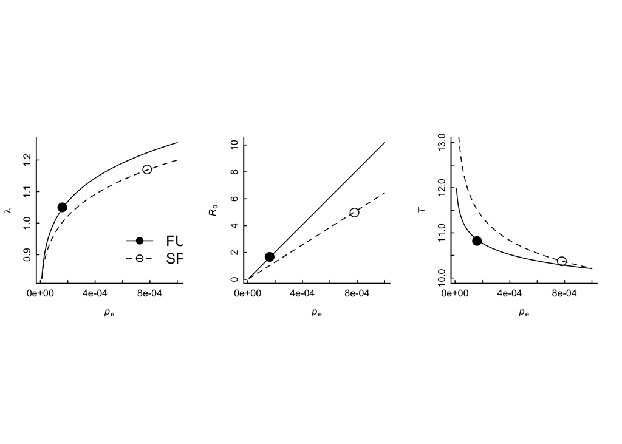

```r
# dev.new()
par(mfrow=c(1,3), mar=c(3,3,1,2)+0.1, bty="l",pty="s", cex.main=1, cex.axis=1, cex.lab=1, tck=0.02, mgp=c(2, 0.3 ,0)) ;

plot(Res.p.est[,1],Res.p.est[,3],type="n",xlab=expression(paste(italic(p)[e])),ylab=expression(lambda))
    lines(Res.p.est[,1],Res.p.est[,3],lty=1)
    lines(Res.p.est[,1],Res.p.est[,4],lty=2)
    points(p.est.FU,1.05, pch=19, cex=2.0); points(p.est.SP,1.17, pch=1, cex=2.0);
    legend(0.0006,1,c("FU", "SP"),pch=c(19,1),lty=c(1,2),bty="n",xjust=0,cex=1.5)

plot(Res.p.est[,1],Res.p.est[,5],type="n",xlab=expression(paste(italic(p)[e])),ylab=expression(paste(italic(R[0]))))
    lines(Res.p.est[,1],Res.p.est[,5],lty=1)
    lines(Res.p.est[,1],Res.p.est[,6],lty=2)
    points(p.est.FU,1.67, pch=19, cex=2.0); points(p.est.SP,4.97, pch=1, cex=2.0)

plot(Res.p.est[,1],Res.p.est[,7],type="n",xlab=expression(paste(italic(p)[e])),ylab=expression(italic(T)),ylim=c(10,13))
    lines(Res.p.est[,1],Res.p.est[,7],lty=1)
    lines(Res.p.est[,1],Res.p.est[,8],lty=2)
    points(p.est.FU,10.82, pch=19, cex=2.0); points(p.est.SP,10.37, pch=1, cex=2.0)
```

```r
## Comment out bootstrap because takes multiple days to run -- way to convert to parallel processing?

# #============================================================================#
# #  Bootstrap lambda, R0 and generation time (see Appendix S4)
# #============================================================================#
#
#
# n.boot=5000
# dem.stats=array(NA,dim=c(n.boot,3,2))
# boot.ESS=array(NA,dim=c(n.boot,2))
#
# M.tl=array(0,dim=c(2*n,2*n))
#
# for(b.samp in 1:n.boot){
#
#   #growth
#
#   size.t=size.t.all[flow.all==0]
#   size.t1=size.t1.all[flow.all==0]
#   site.s=site.all[flow.all==0]
#   test=complete.cases(size.t,size.t1,site.s)
#   size.t=size.t[test]
#   size.t1=size.t1[test]
#   site.s=site.s[test]
#   sample.boot=c(sample(1:735,replace=T),735+sample(1:357,replace=T))
#   size.t.boot=size.t[sample.boot]
#   size.t1.boot=size.t1[sample.boot]
#   fit.grow.gls.boot<-gls(size.t1.boot~site.s+size.t.boot-1,na.action=na.omit,weight=varExp(form=~fitted(.)|site.s),method="ML");
#   g.intercepts.boot=fit.grow.gls.boot$coef[1:2]
#   g.slopes.boot=rep(fit.grow.gls.boot$coef[3],2)
#   var.exp.coef.boot=fit.grow.gls.boot$modelStruct$varStruct
#   sigma.g.boot=fit.grow.gls.boot$sigma
#
#   #survival and flowering
#
#   sample.boot=c(sample(1:827,replace=T),827+sample(1:746,replace=T))
#   size.t.boot=size.t.all[sample.boot]
#   flow.all.boot=flow.all[sample.boot]
#   surv.all.boot=surv.all[sample.boot]
#   fit.flow.boot=glm(flow.all.boot~site.all*size.t.boot-1,family=binomial)
#   f.intercepts.boot=fit.flow.boot$coef[1:2]
#   f.slopes.boot=c(fit.flow.boot$coef[3],fit.flow.boot$coef[3]+fit.flow.boot$coef[4])
#   fit.surv.boot=glm(surv.all.boot~site.all*size.t.boot-1,family=binomial)
#   s.intercepts.boot=fit.surv.boot$coef[1:2]
#   s.slopes.boot=c(fit.surv.boot$coef[3],fit.surv.boot$coef[3]+fit.surv.boot$coef[4])
#
#   #fecundity
#
#   sample.boot=c(sample(1:25,replace=T),25+sample(1:28,replace=T))
#       size.t.f.boot=size.t.f[sample.boot]
#       si.t1.f.boot=si.t1.f[sample.boot]
#       fit.fec.boot=lm(log(si.t1.f.boot)~site.t.f+size.t.f.boot-1)
#
#   #seedlings
#
#   sample.boot=c(sample(1:573,replace=T),573+sample(1:123,replace=T))
#   seedlings.size.t.boot=seedlings.size.t[sample.boot]
#   fit.seedlings.boot=lm(seedlings.size.t.boot~seedlings.site-1)
#
#   #p.est
#
#   sample.boot=c(sample(1:70,replace=T),70+sample(1:42,replace=T))
#   p.est.seeds.t.boot=p.est.seeds.t[sample.boot]
#   p.est.seedlings.boot=p.est.seedlings[sample.boot]
#   est.p.est.boot= sapply(split(p.est.seedlings.boot,p.est.site),sum)/sapply(split(p.est.seeds.t.boot,p.est.site),sum)
#
#
#   for(i in 1:2){
#       p.vec[1]<- s.intercepts.boot[i]
#       p.vec[2]<- s.slopes.boot[i]
#       p.vec[3]<- f.intercepts.boot[i]
#       p.vec[4]<- f.slopes.boot[i]
#       p.vec[5]<- g.intercepts.boot[i]
#       p.vec[6]<- g.slopes.boot[i]
#       p.vec[7]<- sigma.g.boot^2
#       p.vec[8]<- fit.fec.boot$coef[i]
#       p.vec[9]<- fit.fec.boot$coef[3]
#       p.vec[10]<- fit.seedlings.boot$coef[i]
#       p.vec[11]<- summary(fit.seedlings.boot)$sigma^2
#       p.vec[12]<- var.exp.coef.boot[i]
#
#       if(i==1) p.est= est.p.est.boot[1] else p.est=est.p.est.boot[2]
#
#       P<-h*t(outer(y,y,pxy,params=p.vec))
#       B<-h*t(outer(y,y,fxy,params=p.vec))
#
#       M.tl=array(0,dim=c(2*n,2*n))
#       M.tl[1:n,1:n]=P
#       M.tl[1:n,(n+1):(2*n)]=B
#       M.tl[(n+1):(2*n),1:n]=diag(n)
#
#       lam=Re(eigen(M.tl)$values[1]);
#
#   #R0
#
#       M.P=array(0,dim=c(2*n,2*n))
#       M.B=array(0,dim=c(2*n,2*n))
#
#       M.P[1:n,1:n]=P
#       M.P[(n+1):(2*n),1:n]=diag(n)
#
#       M.B[1:n,(n+1):(2*n)]=B
#
#       N<-solve(diag(2*n)-M.P);
#       R<- M.B %*% N
#       R0<-Re(eigen(R)$values[1]);
#
#   #generation time
#
#       T=log(R0)/log(lam)
#       boot.data=c(lam,R0,T)
#
#       dem.stats[b.samp,,i]=boot.data
#
#       if(any(!is.na(boot.data))){
#           boot.ESS[b.samp,i]<-optimize(R0.betas,c(-150,10),maximum=T,tol=0.01)$maximum
#       } else boot.ESS[b.samp,i]=NA
#   }
#   cat("sample ",b.samp,"\n")
# }
#
# getStats=function(x){
#   ci.normal.app=c(mean(x)-1.96*sd(x),mean(x)+1.96*sd(x))
#   res=c(mean(x,na.rm=T),quantile(x,p=c(0.025,0.5,0.975),na.rm=T),ci.normal.app)
#   return(res)
#   }
#
# for(i in 1:2){
#   cat("site ",site.code.l[i],"\n")
#   print(apply(dem.stats[,,i],2,getStats))
#   print(getStats(boot.ESS[,i]))
# }
#
#
# #============================================================================#
# #  Plot: Bootstrap lambda, R0 and generation time (see Appendix S4)
# #============================================================================#
#
#
# dev.new()
# par(mfrow=c(2,4), mar=c(3,3,1,2)+0.1, bty="l",pty="s", cex.main=1, cex.axis=1, cex.lab=1, tck=0.02, mgp=c(2, 0.3 ,0)) ;
#
# main.titles=c(expression(italic(lambda)),expression(italic(R[0])),"Generation time, T",expression("ESS " * italic(beta * scriptstyle(0))))
#
# for(i in 1:2){
#   for(j in 1:3){
#       hist(dem.stats[,j,i][dem.stats[,j,i]<30],xlab=main.titles[j],col="grey",main="")
#       abline(v=mean(dem.stats[,j,i],na.rm=T))
#       abline(v=median(dem.stats[,j,i],na.rm=T),col="blue")
#       abline(v=quantile(dem.stats[,j,i],p=0.025,na.rm=T),col="red")
#       abline(v=quantile(dem.stats[,j,i],p=0.975,na.rm=T),col="red")
#   }
#
#   hist(boot.ESS[,i],col="grey",xlab=main.titles[4],main="")
#   abline(v=mean(boot.ESS[,i],na.rm=T))
#   abline(v=median(boot.ESS[,i],na.rm=T),col="blue")
#   abline(v=quantile(boot.ESS[,i],p=0.025,na.rm=T),col="red")
#   abline(v=quantile(boot.ESS[,i],p=0.975,na.rm=T),col="red")
#   abline(v=f.intercepts[i],col="green",lwd=2)
# }
#
# lam.diff=dem.stats[,1,1]-dem.stats[,1,2]
# mean(lam.diff,na.rm=T)
# quantile(lam.diff,p=c(0.025,0.5,0.975),na.rm=T)
# R0.diff=dem.stats[,2,1]-dem.stats[,2,2]
# mean(R0.diff,na.rm=T)
# quantile(R0.diff,p=c(0.025,0.5,0.975),na.rm=T)
# T.diff=dem.stats[,3,1]-dem.stats[,3,2]
# mean(T.diff,na.rm=T)
# quantile(T.diff,p=c(0.025,0.5,0.975),na.rm=T)
#
# #save(dem.stats,boot.ESS,file="c:\\temp\\ipm sheffield\\bootstrap samples.Rdata")
```